# Predicting Water Safety

Alexander Fortman

```r
knitr::opts_chunk$set(cache = F, warning = F, message = F)
```

# Introduction

This goal of this project is to predict whether or not water would be safe for human consumption given the following data on water samples: 1. pH 2, Hardness 3. Ability to dissolve minerals 4. Chloramines (Disinfectants added to public water systems) 5. Sulfate 6. Conductivity 7. Organic Carbon 8. Trihalomethanes () 9. Turbidity (cloudiness and haziness, measure of clarity in light)

The variable we are predicting is potability which is a binary response (either yes or no).

The data used for this project is available on [Kaggle](https://www.kaggle.com/adityakadiwal/water-potability). The data was originally uploaded in April of 2021.

Since the dataset I am using is already cleaned, this project will focus primarily on the predictive modeling process for relatively smaller datasets, and will employ classic and machine learning techniques.

# Setup

```r
if(require(pacman)==FALSE) install.packages("pacman") # package manager

pacman::p_load(tidyverse, magrittr, # general packages
               DataExplorer, # eda
               skimr, # eda
               corrplot, # correlation plot
               mice, # imputation
               DT # organized tables
)

water = read.csv('water_potability.csv')

set.seed(11) # for reproducability

datatable(water)
```

|  | ph | Hardness | Solids | Chloramines | Sulfate | Conductivity | Organic_carbon | Trihalomethanes | Turbidity | Potability |
| --- | --- | --- | --- | --- | --- | --- | --- | --- | --- | --- |
| 1 |  | 204.890455471336 | 20791.318980747 | 7.30021187318476 | 368.516441349803 | 564.308654172244 | 10.3797830780847 | 86.9909704615088 | 2.96313538063164 | 0 |
| 2 | 3.71608007538699 | 129.422920514944 | 18630.0578579703 | 6.635245883862 |  | 592.885359134852 | 15.1800131163573 | 56.3290762845176 | 4.50065627494241 | 0 |
| 3 | 8.0991241892984 | 224.236259393558 | 19909.5417322924 | 9.27588360269409 |  | 418.606213064481 | 16.868636929551 | 66.4200925117637 | 3.05593374966417 | 0 |
| 4 | 8.31676588421468 | 214.373394085623 | 22018.4174407753 | 8.05933237743854 | 356.886135643057 | 363.266516164244 | 18.4365244954933 | 100.34167436508 | 4.62877053683708 | 0 |
| 5 | 9.09222345629096 | 181.101509236125 | 17978.9863389263 | 6.54659997420794 | 310.135737524204 | 398.410813381845 | 11.5582794434464 | 31.9979927274247 | 4.07507542543003 | 0 |
| 6 | 5.58408663845609 | 188.313323769616 | 28748.6877390461 | 7.54486878877965 | 326.678362911674 | 280.467915933488 | 8.39973464015276 | 54.9178618419945 | 2.55970822755652 | 0 |
| 7 | 10.2238621645288 | 248.07173527014 | 28749.7165435282 | 7.5134084658313 | 393.663395515096 | 283.651633507845 | 13.7896953175199 | 84.6035561740236 | 2.67298873693478 | 0 |
| 8 | 8.63584871850073 | 203.361522584571 | 13672.0917639016 | 4.5630086855997 | 303.309771159281 | 474.607644942449 | 12.3638166987053 | 62.7983089629252 | 4.40142471544548 | 0 |
| 9 |  | 118.988579090252 | 14285.5838542245 | 7.80417355307309 | 268.646940746221 | 389.375565871261 | 12.7060489686579 | 53.9288457675122 | 3.59501718095762 | 0 |
| 10 | 11.1802844707216 | 227.231469237975 | 25484.5084909879 | 9.07720001691439 | 404.04163468409 | 563.885481481095 | 17.927806411285 | 71.9766010322192 | 4.3705619366555 | 0 |

[output cut: 3266 more lines]

# Pre-processing

Given the nature of our predictor variables, we will not have to change the datatypes of the predictor variables. We will only need to recode the target variable (Potability) to be a factor (for machine learning algorithms). 0 will indicate that the water is not safe to drink, whereas 1 will show that the water sample was safe to drink.

```r
class(water$Potability)
```

```
## [1] "integer"
```

```r
water$Potability %<>% as.factor()
class(water$Potability) # verify that recode worked
```

```
## [1] "factor"
```

```r
water %<>% rename(THM = Trihalomethanes, Safe = Potability)
```

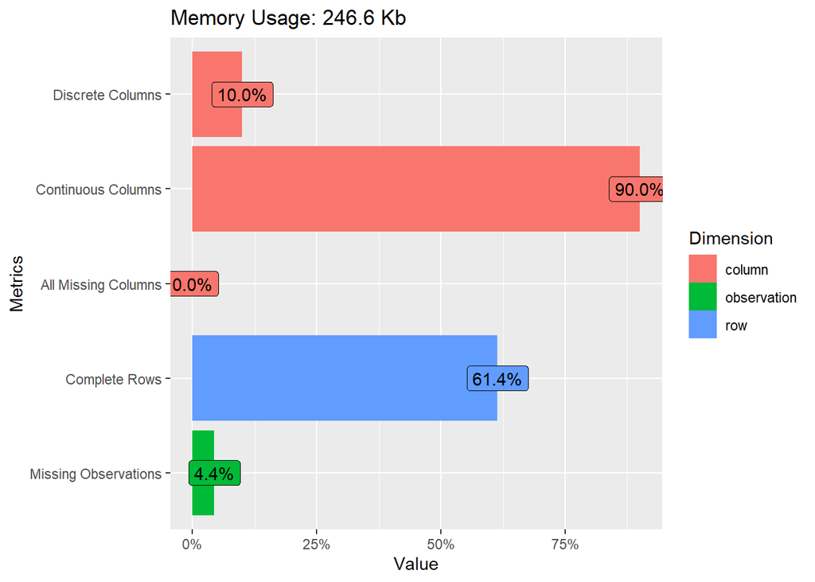

```r
plot_intro(water)
```

4.4% of our data missing and 61.4% of our observations have no missing values. From this view, it looks like we will be fine to impute the data. Let’s take a deeper look into the missing data in the nest section.

# Data Exploration and Processing

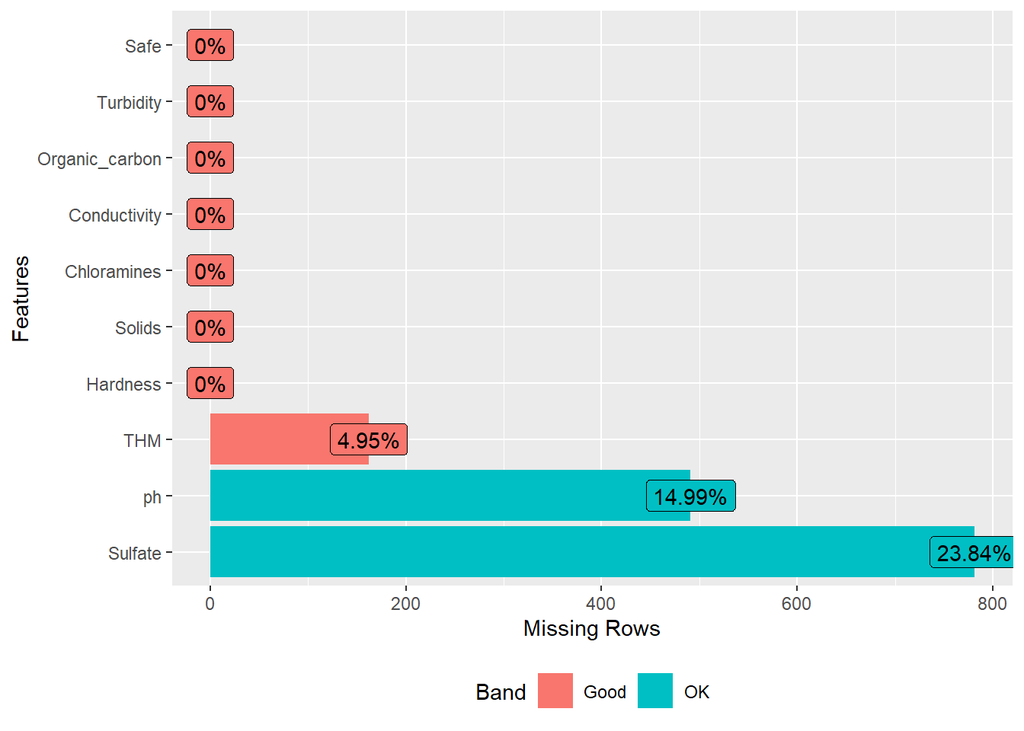

```r
plot_missing(water)
```

```r
water %<>% mutate(
  M_ph = ifelse(is.na(water$ph),1,0) %>% as.factor(),
  M_Sulfate = ifelse(is.na(water$Sulfate),1,0) %>% as.factor()
)
```

## Imputation

We will use the [MICE package](https://cran.r-project.org/web/packages/mice/index.html) for imputation, employing the [PMM](https://stefvanbuuren.name/fimd/sec-pmm.html) (predictive mean matching) instead of simple mean or median imputation to hopefully improve prediction power of the models later.

```r
imp_data =  mice(data = water, m = 10, method = "pmm", maxit = 5, seed = 11, printFlag = F)

water = mice::complete(imp_data)
```

```r
sum(is.na(water)) # verify that imputation worked
```

```
## [1] 0
```

## Histograms

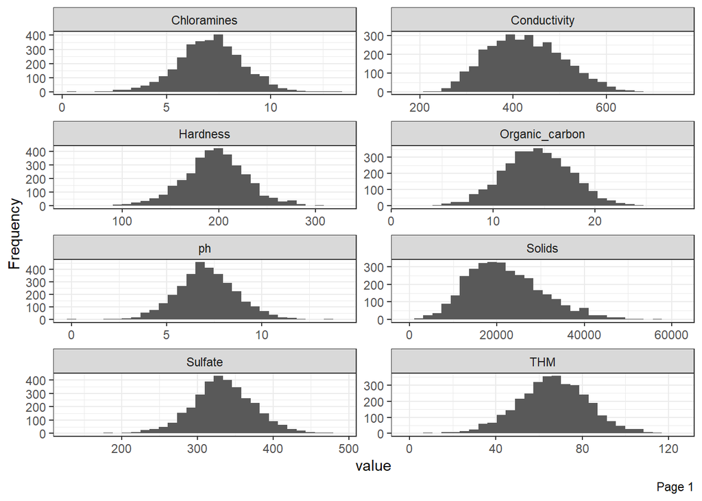

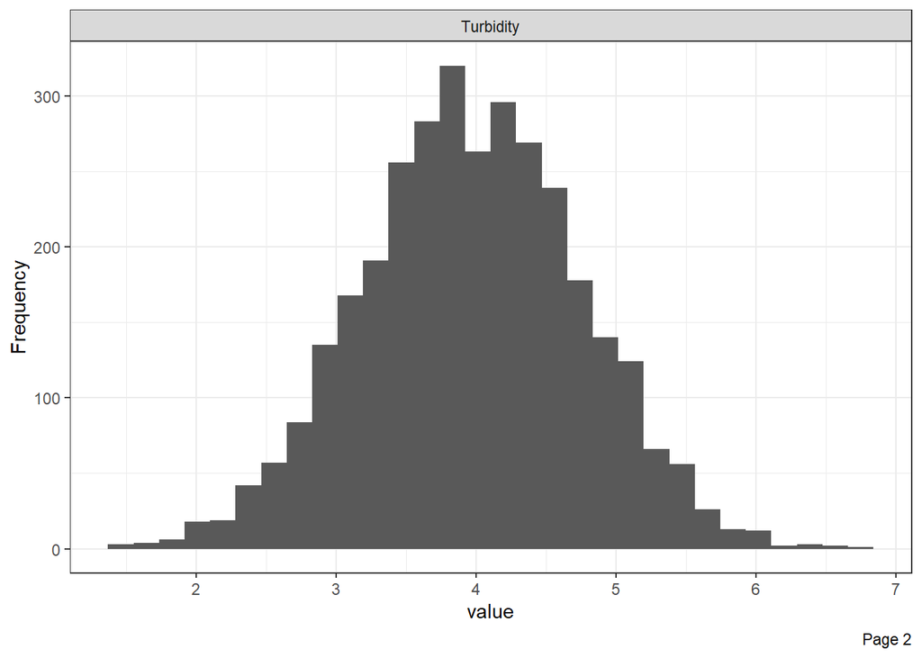

```r
plot_histogram(water, ncol = 2, ggtheme = theme_bw())
```

All histograms appear to be good. They are all approximately normal, with `Solids` being right-skewed.

```r
prop.table(table(water$Safe)) # proportion of samples that are safe
```

```
##
##         0         1
## 0.6098901 0.3901099
```

The proportions for our response variable are balanced. We do not need to use any class balancing techniques.

# Correlation Plot

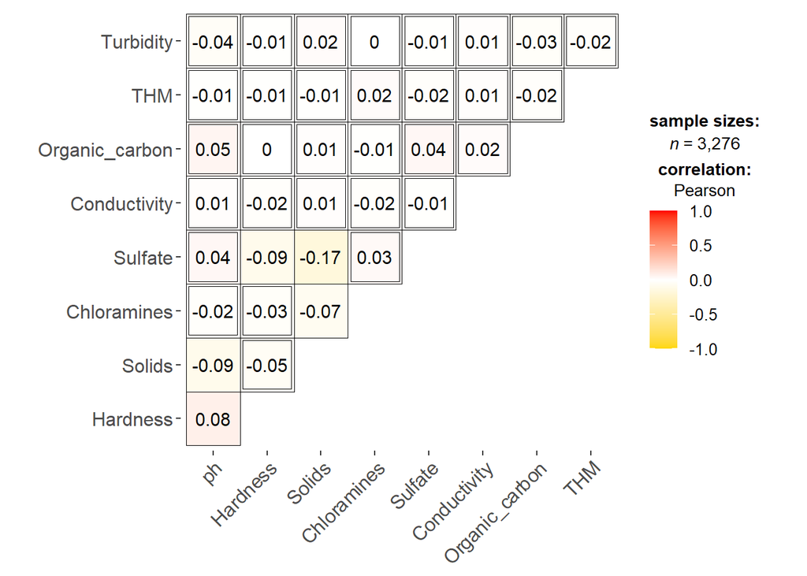

```r
nums = dplyr::select(water,-c(Safe, M_ph, M_Sulfate))
pacman::p_load(ggstatsplot, ggcorrplot)
ggcorrmat(nums, pch = 0, colors = c('gold','white','red'))
```

Because the predictors do not appear to be correlated and we only have 9 predictors, we will not remove any variables and will proceed with modeling. Below is the dataset we will use for modeling.

## Final Dataframe

```r
water %>% datatable() %>% formatRound(columns = c('ph', 'Hardness', 'Solids', 'Chloramines', 'Sulfate', 'Conductivity', 'Organic_carbon', 'THM', 'Turbidity'), digits = 2)
```

|  | ph | Hardness | Solids | Chloramines | Sulfate | Conductivity | Organic_carbon | THM | Turbidity | Safe | M_ph | M_Sulfate |
| --- | --- | --- | --- | --- | --- | --- | --- | --- | --- | --- | --- | --- |
| 1 | 7.70335682138211 | 204.890455471336 | 20791.318980747 | 7.30021187318476 | 368.516441349803 | 564.308654172244 | 10.3797830780847 | 86.9909704615088 | 2.96313538063164 | 0 | 1 | 0 |
| 2 | 3.71608007538699 | 129.422920514944 | 18630.0578579703 | 6.635245883862 | 382.318960695273 | 592.885359134852 | 15.1800131163573 | 56.3290762845176 | 4.50065627494241 | 0 | 0 | 1 |
| 3 | 8.0991241892984 | 224.236259393558 | 19909.5417322924 | 9.27588360269409 | 406.476119295458 | 418.606213064481 | 16.868636929551 | 66.4200925117637 | 3.05593374966417 | 0 | 0 | 1 |
| 4 | 8.31676588421468 | 214.373394085623 | 22018.4174407753 | 8.05933237743854 | 356.886135643057 | 363.266516164244 | 18.4365244954933 | 100.34167436508 | 4.62877053683708 | 0 | 0 | 0 |
| 5 | 9.09222345629096 | 181.101509236125 | 17978.9863389263 | 6.54659997420794 | 310.135737524204 | 398.410813381845 | 11.5582794434464 | 31.9979927274247 | 4.07507542543003 | 0 | 0 | 0 |
| 6 | 5.58408663845609 | 188.313323769616 | 28748.6877390461 | 7.54486878877965 | 326.678362911674 | 280.467915933488 | 8.39973464015276 | 54.9178618419945 | 2.55970822755652 | 0 | 0 | 0 |
| 7 | 10.2238621645288 | 248.07173527014 | 28749.7165435282 | 7.5134084658313 | 393.663395515096 | 283.651633507845 | 13.7896953175199 | 84.6035561740236 | 2.67298873693478 | 0 | 0 | 0 |
| 8 | 8.63584871850073 | 203.361522584571 | 13672.0917639016 | 4.5630086855997 | 303.309771159281 | 474.607644942449 | 12.3638166987053 | 62.7983089629252 | 4.40142471544548 | 0 | 0 | 0 |
| 9 | 9.61022034489963 | 118.988579090252 | 14285.5838542245 | 7.80417355307309 | 268.646940746221 | 389.375565871261 | 12.7060489686579 | 53.9288457675122 | 3.59501718095762 | 0 | 1 | 0 |
| 10 | 11.1802844707216 | 227.231469237975 | 25484.5084909879 | 9.07720001691439 | 404.04163468409 | 563.885481481095 | 17.927806411285 | 71.9766010322192 | 4.3705619366555 | 0 | 0 | 0 |

[output cut: 3266 more lines]

# Modeling

The models I will use are:

- Stepwise Logistic Regression
- Naive Bayes
- Linear Support Vector Machine
- k-Nearest Neighbors
- Random Forest
- [XGBoost](https://xgboost.readthedocs.io/en/stable/)
- [CatBoost](https://catboost.ai/)
- Neural Network

## Setup

Below are all the packages we will need to fit all the models and measure performance:

```r
pacman::p_load(caret, # ml library
               ROCR,
               pROC,
               rpart,
               ranger,# random forest
               devtools, # downloading catboost
               doParallel, # parallel computing
               e1071, # svm model
               kernlab, # svm model
               arm, # naive bayes model
               nnet
               )

if(require(catboost)==FALSE) devtools::install_url('https://github.com/catboost/catboost/releases/download/v0.20/catboost-R-Windows-0.20.tgz', INSTALL_opts = c("--no-multiarch", "--no-test-load"))
pacman::p_load(catboost)
```

The below function is for clearing parallelization errors.

```r
undoParallel <- function() {
  env <- foreach:::.foreachGlobals
  rm(list=ls(name=env), pos=env)
}
```

Let’s create our training and test sets. Since we’re using cross-validation, we will set parameters for that as well.

```r
water$Safe %<>% fct_recode("No" = '0', "Yes" = '1')

trainIndex<-createDataPartition(water$Safe, p=0.9, list=FALSE, times=1)
cvindx<-createFolds(trainIndex, k=5, returnTrain = TRUE)
ctrl <- trainControl(method="cv", index=cvindx, summaryFunction = twoClassSummary, classProbs = TRUE)

metric = "ROC"

training = water[trainIndex,] # training
test = water[-trainIndex,] # test
t_label = test$Safe
```

## Stepwise Logistic Regression

```r
lrstep = train(Safe~.,
               data=training,
               method="glmStepAIC",
               direction="both",
               metric=metric,
               trControl=ctrl,
               trace=F)
```

```r
lrstep
```

```
## Generalized Linear Model with Stepwise Feature Selection
##
## 2950 samples
##   11 predictor
##    2 classes: 'No', 'Yes'
##
## No pre-processing
## Resampling: Cross-Validated (10 fold)
## Summary of sample sizes: 2360, 2361, 2360, 2360, 2359
## Resampling results:
##
##   ROC        Sens       Spec
##   0.4907454  0.9977778  0.003482358
```

## Naive Bayes

```r
nb = train(Safe~.,
           data=training,
           method="bayesglm",
           metric=metric,
           trControl=ctrl,
           trace = F)
```

```r
nb
```

```
## Bayesian Generalized Linear Model
##
## 2950 samples
##   11 predictor
##    2 classes: 'No', 'Yes'
##
## No pre-processing
## Resampling: Cross-Validated (10 fold)
## Summary of sample sizes: 2360, 2361, 2360, 2360, 2359
## Resampling results:
##
##   ROC        Sens       Spec
##   0.5020758  0.9961263  0.007825574
```

## Linear SVM

```r
svm = train(Safe~.,
             data = training,
             method = "svmLinear",
             metric = metric,
             trControl = ctrl,
             trace = F)
```

[output not shown]

```r
svm
```

```
## Support Vector Machines with Linear Kernel
##
## 2950 samples
##   11 predictor
##    2 classes: 'No', 'Yes'
##
## No pre-processing
## Resampling: Cross-Validated (10 fold)
## Summary of sample sizes: 2360, 2361, 2360, 2360, 2359
## Resampling results:
##
##   ROC        Sens  Spec
##   0.4899959  1     0
##
## Tuning parameter 'C' was held constant at a value of 1
```

## k-Nearest Neighbors

```r
knnGrid <-  expand.grid(k = c(1:10))

knn = train(Safe~.,
           data = training,
           tuneGrid = knnGrid,
           method = "knn",
           metric = metric,
           trControl = ctrl)
```

```r
knn
```

```
## k-Nearest Neighbors
##
## 2950 samples
##   11 predictor
##    2 classes: 'No', 'Yes'
##
## No pre-processing
## Resampling: Cross-Validated (10 fold)
## Summary of sample sizes: 2360, 2361, 2360, 2360, 2359
## Resampling results across tuning parameters:
##
##   k   ROC        Sens       Spec
##    1  0.5186959  0.6413353  0.3960565
##    2  0.5086949  0.6458558  0.3701092
##    3  0.5105565  0.6892212  0.3325430
##    4  0.5112855  0.6916840  0.3278126
##    5  0.5137456  0.7243004  0.3064485
##    6  0.5179011  0.7283852  0.2958098
##    7  0.5218644  0.7579531  0.2679658
##    8  0.5250147  0.7516791  0.2798723
##    9  0.5247547  0.7784321  0.2671317
##   10  0.5293888  0.7812772  0.2623557
##
## ROC was used to select the optimal model using the largest value.
## The final value used for the model was k = 10.
```

## Random Forest

```r
rfGrid <- expand.grid(
  .mtry = c(6,8,10),
  .splitrule = c("extratrees","gini"),
  .min.node.size = c(5)
)
```

```r
cl <- makePSOCKcluster(detectCores()-1)

registerDoParallel(cl)

rf = train(Safe~.,
           tuneGrid=rfGrid,
           data=training,
           method="ranger",
           metric=metric,
           num.trees=500,
           importance="impurity",
           trControl=ctrl )

stopCluster(cl)
```

```r
rf
```

```
## Random Forest
##
## 2950 samples
##   11 predictor
##    2 classes: 'No', 'Yes'
##
## No pre-processing
## Resampling: Cross-Validated (10 fold)
## Summary of sample sizes: 2360, 2361, 2360, 2360, 2359
## Resampling results across tuning parameters:
##
##   mtry  splitrule   ROC        Sens       Spec
##    6    extratrees  0.6760632  0.9183499  0.2676807
##    6    gini        0.6692847  0.8628693  0.3501501
##    8    extratrees  0.6828971  0.9172362  0.2870960
##    8    gini        0.6715381  0.8507914  0.3657402
##   10    extratrees  0.6816417  0.8994659  0.2993256
##   10    gini        0.6729069  0.8567084  0.3656168
##
## Tuning parameter 'min.node.size' was held constant at a value of 5
## ROC was used to select the optimal model using the largest value.
## The final values used for the model were mtry = 8, splitrule = extratrees
##  and min.node.size = 5.
```

## XGBoost

```r
xgbGrid <- expand.grid(nrounds = c(100, 200),
                       max_depth = c(15, 20, 25),
                       colsample_bytree = seq(0.7, 0.9, length.out = 5),
                       eta = 0.1,
                       gamma=0,
                       min_child_weight = 1,
                       subsample = 1
                      )
```

```r
cl = makePSOCKcluster(detectCores()-1)

registerDoParallel(cl)

xgbt <- train(Safe~.,
              data = training,
              method = 'xgbTree',
              metric = metric,
              tuneGrid = xgbGrid,
              trControl = ctrl,
              verbosity = 0)

stopCluster(cl)

undoParallel()
```

```r
xgbt
```

```
## eXtreme Gradient Boosting
##
## 2950 samples
##   11 predictor
##    2 classes: 'No', 'Yes'
##
## No pre-processing
## Resampling: Cross-Validated (10 fold)
## Summary of sample sizes: 2360, 2361, 2360, 2360, 2359
## Resampling results across tuning parameters:
##
##   max_depth  colsample_bytree  nrounds  ROC        Sens       Spec
##   15         0.70              100      0.6402670  0.8317493  0.3554993
##   15         0.70              200      0.6404852  0.8117415  0.3747242
##   15         0.75              100      0.6411092  0.8202940  0.3628178
##   15         0.75              200      0.6443432  0.7996606  0.3686238
##   15         0.80              100      0.6521140  0.8162860  0.3716209
##   15         0.80              200      0.6480927  0.8108137  0.3716617
##   15         0.85              100      0.6523774  0.8079984  0.3929202
##   15         0.85              200      0.6500987  0.8008110  0.3883550
##   15         0.90              100      0.6515974  0.8096697  0.3746449
##   15         0.90              200      0.6523266  0.8054055  0.3891456
##   20         0.70              100      0.6381145  0.8063087  0.3571717
##   20         0.70              200      0.6364308  0.8041554  0.3720194
##   20         0.75              100      0.6389406  0.8237295  0.3765939
##   20         0.75              200      0.6400879  0.8114870  0.3835371
##   20         0.80              100      0.6496069  0.8187448  0.3719281
##   20         0.80              200      0.6501039  0.8102597  0.3798083
##   20         0.85              100      0.6464381  0.8124498  0.3815365
##   20         0.85              200      0.6447068  0.8031548  0.3894896
##   20         0.90              100      0.6496816  0.8120397  0.3827257
##   20         0.90              200      0.6464738  0.8010156  0.3956777
##   25         0.70              100      0.6330312  0.8236141  0.3466282
##   25         0.70              200      0.6349982  0.8135751  0.3726263
##   25         0.75              100      0.6416743  0.8231101  0.3600564
##   25         0.75              200      0.6437212  0.8048725  0.3696919
##   25         0.80              100      0.6435244  0.8097473  0.3587855
##   25         0.80              200      0.6431098  0.8097295  0.3797313
##   25         0.85              100      0.6564085  0.8215506  0.3742428
##   25         0.85              200      0.6546928  0.8158325  0.3934462
##   25         0.90              100      0.6516836  0.8131573  0.3790901
##   25         0.90              200      0.6491498  0.8004452  0.3981617
##
## Tuning parameter 'eta' was held constant at a value of 0.1
## Tuning
##  parameter 'min_child_weight' was held constant at a value of 1
##
## Tuning parameter 'subsample' was held constant at a value of 1
## ROC was used to select the optimal model using the largest value.
## The final values used for the model were nrounds = 100, max_depth = 25, eta
##  = 0.1, gamma = 0, colsample_bytree = 0.85, min_child_weight = 1 and
##  subsample = 1.
```

## CatBoost

For this model, we will split the training data into its label and predictors.

```r
x = dplyr::select(training, -Safe)
y = training$Safe

grid_cb <- expand.grid(depth = c(4, 6, 8),
                    learning_rate = 0.1,
                    iterations = 100,
                    l2_leaf_reg = 1e-3,
                    rsm = 0.95,
                    border_count = 64)
```

```r
cbt <- train(x, make.names(y),
                  method = catboost.caret,
                  metric = metric,
                  tuneGrid = grid_cb,
                  trControl = ctrl,
                  logging_level = "Silent")
```

```r
cbt
```

```
## Catboost
##
## 2950 samples
##   11 predictor
##    2 classes: 'No', 'Yes'
##
## No pre-processing
## Resampling: Cross-Validated (10 fold)
## Summary of sample sizes: 2360, 2361, 2360, 2360, 2359
## Resampling results across tuning parameters:
##
##   depth  ROC        Sens       Spec
##   4      0.6538509  0.9062906  0.2728914
##   6      0.6753962  0.8714677  0.3346444
##   8      0.6698226  0.8564389  0.3631608
##
## Tuning parameter 'learning_rate' was held constant at a value of 0.1
##
## Tuning parameter 'rsm' was held constant at a value of 0.95
## Tuning
##  parameter 'border_count' was held constant at a value of 64
## ROC was used to select the optimal model using the largest value.
## The final values used for the model were depth = 6, learning_rate =
##  0.1, iterations = 100, l2_leaf_reg = 0.001, rsm = 0.95 and border_count = 64.
```

## Neural Network

```r
nnetGrid = expand.grid(.size = 1:3,
                       .decay = seq(from = .01, to = .06, by = .01))
```

```r
cl = makePSOCKcluster(detectCores()-1)

registerDoParallel(cl)

nnet = train(Safe~.,
           data = training,
           method = "nnet",
           tuneGrid = nnetGrid,
           metric = metric,
           MaxNWts = 100,
           trControl = ctrl,
           trace = F)

stopCluster(cl)
```

```r
nnet
```

```
## Neural Network
##
## 2950 samples
##   11 predictor
##    2 classes: 'No', 'Yes'
##
## No pre-processing
## Resampling: Cross-Validated (10 fold)
## Summary of sample sizes: 2360, 2361, 2360, 2360, 2359
## Resampling results across tuning parameters:
##
##   size  decay  ROC        Sens       Spec
##   1     0.01   0.4996487  0.9994236  0.0033997507
##   1     0.02   0.5031430  0.9978006  0.0052409812
##   1     0.03   0.4942770  0.9931120  0.0207196665
##   1     0.04   0.5007307  1.0000000  0.0000000000
##   1     0.05   0.4996833  0.9994236  0.0008264463
##   1     0.06   0.4996833  0.9994236  0.0008264463
##   2     0.01   0.5024187  0.9971182  0.0033844943
##   2     0.02   0.4986848  0.9994236  0.0043049061
##   2     0.03   0.4982604  0.9735288  0.0334179440
##   2     0.04   0.4967468  0.9806868  0.0210373730
##   2     0.05   0.4918874  0.9966839  0.0017153352
##   2     0.06   0.5023180  0.9613051  0.0666224363
##   3     0.01   0.5046788  0.9788264  0.0328369801
##   3     0.02   0.5024273  0.9713762  0.0308107671
##   3     0.03   0.4948167  0.9811607  0.0349256268
##   3     0.04   0.5005894  0.9971390  0.0051352509
##   3     0.05   0.5011822  0.9927270  0.0076731339
##   3     0.06   0.5198718  0.9394663  0.1246911177
##
## ROC was used to select the optimal model using the largest value.
## The final values used for the model were size = 3 and decay = 0.06.
```

# Model Evaluation

```r
models = c('lrstep','nb','svm','knn','rf','xgbt','cbt','nnet')
accuracy = c()
auc = c()
sensitivity = c()
specificity = c()
precision = c()
recall = c()
```

```r
for (i in models){
  rocp = predict(eval(as.name(i)), newdata = test, type = "prob")
  roc = roc(response = test$Safe, predictor = rocp$Yes)
  auc = append(auc, roc$auc[1])

  pred = predict(eval(as.name(i)), newdata = test)
  cm = confusionMatrix(pred, test$Safe)

  accuracy = append(accuracy, unname(cm$overall[1]))
  sensitivity = append(sensitivity, unname(cm$byClass['Sensitivity']))
  specificity = append(specificity, unname(cm$byClass['Specificity']))
  precision = append(precision, unname(cm$byClass['Precision']))
  recall = append(recall, unname(cm$byClass['Recall']))

}

model = c("Stepwise Logistic Regression","Naive Bayes","Linear SVM","k-Nearest Neighbors","Random Forest","XGBoost","Catboost","Neural Network")
results = data.frame(model, accuracy, auc, sensitivity, specificity, precision, recall)
```

```r
datatable(results)
```

|  | model | accuracy | auc | sensitivity | specificity | precision | recall |
| --- | --- | --- | --- | --- | --- | --- | --- |
| 1 | Stepwise Logistic Regression | 0.610429447852761 | 0.543584062042496 | 1 | 0 | 0.610429447852761 | 1 |
| 2 | Naive Bayes | 0.610429447852761 | 0.517390100106833 | 1 | 0 | 0.610429447852761 | 1 |
| 3 | Linear SVM | 0.610429447852761 | 0.517033988841847 | 1 | 0 | 0.610429447852761 | 1 |
| 4 | k-Nearest Neighbors | 0.552147239263804 | 0.464151465991374 | 0.748743718592965 | 0.244094488188976 | 0.608163265306122 | 0.748743718592965 |
| 5 | Random Forest | 0.690184049079755 | 0.684228227752938 | 0.914572864321608 | 0.338582677165354 | 0.684210526315789 | 0.914572864321608 |
| 6 | XGBoost | 0.659509202453988 | 0.658528864796423 | 0.834170854271357 | 0.385826771653543 | 0.680327868852459 | 0.834170854271357 |
| 7 | Catboost | 0.668711656441718 | 0.63407589126736 | 0.879396984924623 | 0.338582677165354 | 0.675675675675676 | 0.879396984924623 |
| 8 | Neural Network | 0.601226993865031 | 0.558184623906936 | 0.924623115577889 | 0.094488188976378 | 0.615384615384615 | 0.924623115577889 |